# Comparing different clustering methods

Kevin Wang

07 Dec 2019

# Aim of this document

This is a demonstration of the `ggiraph` package’s interactive visualisation capability. Also, since `patchwork` was recently put on CRAN, “side-by-side interactive plotting” just got easier!

I will perform the PCA, tSNE and UMAP dimensionality reduction on the `iris` data.

Just so you know that I know:

- Yes, `iris` data is overused, but hey! It is only a quick coding demo!
- Yes, I know about `plotly`, it also has the side-by-side option, but it is very painful when there are multiple plotting aesthetics.

```r
library(ggiraph)
library(patchwork)
library(tidyverse)
library(Rtsne)
library(umap)
```

# Computing the dimensionality reduction objects

```r
## We:
## + convert the iris data to a tibble
## + remove one duplicated row
## + add unique identifier to each row

iris_tbl = iris %>%
  as_tibble() %>%
  distinct() %>%
  tibble::rownames_to_column("id")

iris_tbl
```

```
## # A tibble: 149 x 6
##    id    Sepal.Length Sepal.Width Petal.Length Petal.Width Species
##    <chr>        <dbl>       <dbl>        <dbl>       <dbl> <fct>
##  1 1              5.1         3.5          1.4         0.2 setosa
##  2 2              4.9         3            1.4         0.2 setosa
##  3 3              4.7         3.2          1.3         0.2 setosa
##  4 4              4.6         3.1          1.5         0.2 setosa
##  5 5              5           3.6          1.4         0.2 setosa
##  6 6              5.4         3.9          1.7         0.4 setosa
##  7 7              4.6         3.4          1.4         0.3 setosa
##  8 8              5           3.4          1.5         0.2 setosa
##  9 9              4.4         2.9          1.4         0.2 setosa
## 10 10             4.9         3.1          1.5         0.1 setosa
## # … with 139 more rows
```

```r
## Computing the PCA, TSNE and UMAP objects
iris_pca = prcomp(iris_tbl %>% select_if(is.numeric))
iris_tsne = Rtsne(iris_tbl %>% select_if(is.numeric))
iris_umap = umap(iris_tbl %>% select_if(is.numeric))
```

# Preparing the plotting data and static plots

The main function we will use is `geom_point_interactive` from the `ggiraph` package. It behaves just like `geom_point`, but with two additional aesthetics. The `data_id` aesthetic is critical to link observations between plots and the `tooltip` aesthetic is optional but nice to have when mouse over a point. After making these plots, the `girafe` function using the same syntax in `patchwork` will allow us to make a pretty interactive plot!

```r
## Getting two reduced dimensions for each method
iris_plotdf = iris_tbl %>%
  mutate(
    pca_1 = iris_pca$x[,1],
    pca_2 = iris_pca$x[,2],
    tsne_1 = iris_tsne$Y[,1],
    tsne_2 = iris_tsne$Y[,2],
    umap_1 = iris_umap$layout[,1],
    umap_2 = iris_umap$layout[,2]
  )



p1 = iris_plotdf %>%
  ggplot(aes(x = pca_1, y = pca_2,
             colour = Species,
             tooltip = id,
             data_id = id)) +
  geom_point_interactive() +
  labs(title = "PCA")

p2 = iris_plotdf %>%
  ggplot(aes(x = tsne_1, y = tsne_2,
             colour = Species,
             tooltip = id,
             data_id = id)) +
  geom_point_interactive() +
  labs(title = "tSNE")

p3 = iris_plotdf %>%
  ggplot(aes(x = umap_1, y = umap_2,
             colour = Species,
             tooltip = id,
             data_id = id)) +
  geom_point_interactive() +
  labs(title = "UMAP")
```

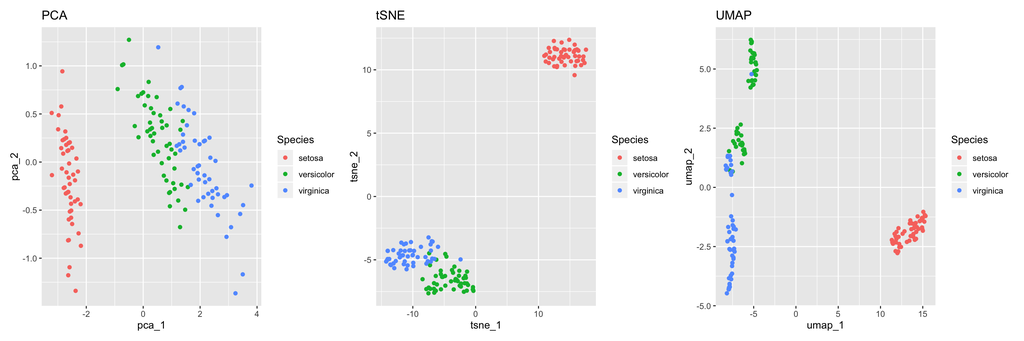

```r
p1 + p2 + p3
```

At this point, `p1 + p2 + p3` are combined together as a static plot thanks to `patchwork`. But making it iterative is just one line.

## The magical interactive visualisation

```r
girafe(code = print(p1 + p2 + p3),
       width_svg = 15, height_svg = 5)
```

[interactive chart not shown]

## Extensions

For the `tidyverse` fanatics (myself included), you will see that we have made three plots with similar structures and cringe a little bit. Here is another way to make similar plot by pivoting.

```r
iris_long_plotdf = iris_plotdf %>%
  tidyr::pivot_longer(cols = matches("1|2"),
                      names_to = c("method", "dim"),
                      names_sep = "_") %>%
  tidyr::pivot_wider(names_from = dim,
                     values_from = value)

iris_long_plotdf
```

```
## # A tibble: 447 x 9
##    id    Sepal.Length Sepal.Width Petal.Length Petal.Width Species method   `1`
##    <chr>        <dbl>       <dbl>        <dbl>       <dbl> <fct>   <chr>  <dbl>
##  1 1              5.1         3.5          1.4         0.2 setosa  pca    -2.67
##  2 1              5.1         3.5          1.4         0.2 setosa  tsne   13.6
##  3 1              5.1         3.5          1.4         0.2 setosa  umap   13.9
##  4 2              4.9         3            1.4         0.2 setosa  pca    -2.70
##  5 2              4.9         3            1.4         0.2 setosa  tsne   16.1
##  6 2              4.9         3            1.4         0.2 setosa  umap   12.0
##  7 3              4.7         3.2          1.3         0.2 setosa  pca    -2.88
##  8 3              4.7         3.2          1.3         0.2 setosa  tsne   16.1
##  9 3              4.7         3.2          1.3         0.2 setosa  umap   11.9
## 10 4              4.6         3.1          1.5         0.2 setosa  pca    -2.74
## # … with 437 more rows, and 1 more variable: `2` <dbl>
```

```r
p4 = iris_long_plotdf %>%
  ggplot(aes(x = `1`, y = `2`,
             colour = Species,
             tooltip = id,
             data_id = id)) +
  geom_point_interactive() +
  facet_grid(~method, scales = "free")

girafe(code = print(p4),
       width_svg = 10, height_svg = 5)
```

[interactive chart not shown]